# ggplot2

Kenneth Roy Cabrera Torres  
21 Octubre de 2014

### ¿Qué es ggplot2? I

- Es una construcción de la “Gramática de las gráficas” (Grammar Graphics) propuesta por Leland Wilkinson.
- Escrito por Hadley Wickham (como estudiante de Iowa State).
- Está disponible en CRAN y se installa como un paquete del CRAN.

### ¿Qué es ggplot2? II

- La gramática de las gráficas representa una abtracción de gráficas e ideas.
- Similar a pensar en “verbos”, “sustantivos” y “adjetivos” para las gráficas.
- La teoría propone una construcción de gráficas mediante una sucesión de elementos similar a un lenguaje.
- La idea es acortar la distancia entre lo que se piensa y lo que se grafica.

### ¿Qué es ggplot2? III

“En resumen, la gramática nos dice que una gráfica estadística es un mapa de los datos a unos atributos estéticos (color, forma, tamaño) de unos objetos geométricos (puntos, lineas, barras). La gráfica tendrá transformaciones estadísticas que se trazan en sistemas de coordenadas específicas”

Del libro “ggplot2”

### La función qplot()

- Trabaja similar a la función *plot* en el sistema básico.
- Se le indica una base de datos, unos elementos *estéticos* y una *geometría*.
- Se recomienda trabajar con la composición para tener más dominio de la gramática.

### Paquete ggplot2

```r
require(ggplot2)
```

### Base de datos

```r
help(mpg)
str(mpg)
head(mpg)
```

### Primera gráfica

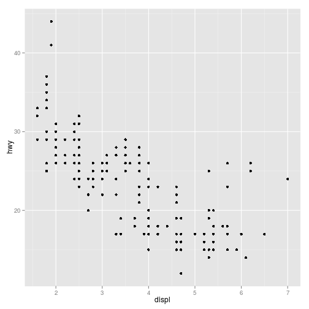

```r
g1 <- ggplot(mpg, aes(displ, hwy))
g1 + geom_point()
```

### Segunda gráfica

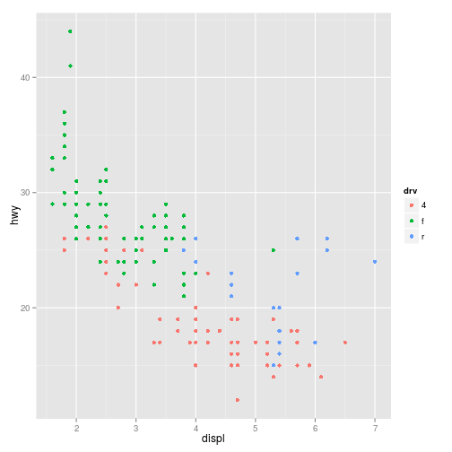

```r
g1 <- ggplot(mpg, aes(displ, hwy, col = drv))
g1 + geom_point()
```

### Adición de una "geom_"

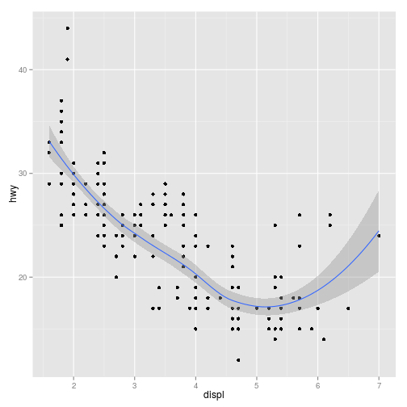

```r
g1 <- ggplot(mpg, aes(displ, hwy))
g1 + geom_point() + geom_smooth()
```

### Histograma

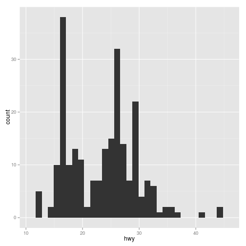

```r
g1 <- ggplot(mpg, aes(hwy))
g1 + geom_histogram()
```

### Histogramas

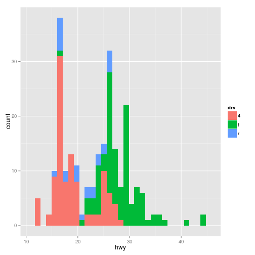

```r
g1 <- ggplot(mpg, aes(hwy, fill = drv))
g1 + geom_histogram()
```

### Facetas (páneles) I

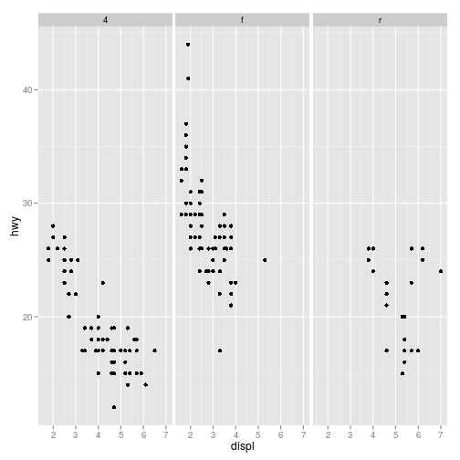

```r
g1 <- ggplot(mpg, aes(displ, hwy))
g1 + geom_point() + facet_grid( . ~ drv)
```

### Facetas (páneles) II

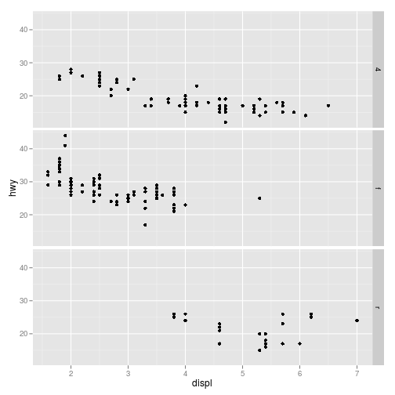

```r
g1 <- ggplot(mpg, aes(displ, hwy))
g1 + geom_point() + facet_grid( drv ~ .)
```

### Facetas (páneles) III

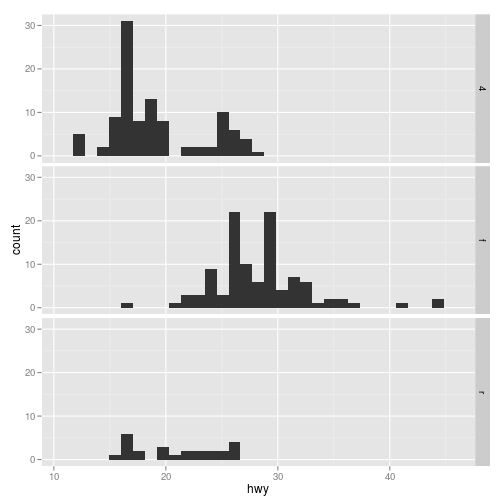

```r
g1 <- ggplot(mpg, aes(hwy))
g1 + geom_histogram() + facet_grid( drv ~ .)
```

### Calidad del aire

```r
require(dataset)
require(airquality)
help(airquality)
str(airquality)
head(airquality)
```

### Calidad del aire I

```r
require(ggplot2)
g1 <- ggplot(airquality, aes(Ozone))
g1 + geom_histogram()
```

### Calidad del aire II

```r
require(ggplot2)
g1 <- ggplot(airquality, aes(Ozone, fill = factor(Month)))
g1 + geom_histogram()
```

### Distribución

```r
require(ggplot2)
g1 <- ggplot(airquality, aes(Ozone))
g1 + geom_density()
```

### Distribuciones

```r
require(ggplot2)
g1 <- ggplot(airquality, aes(Ozone, col = factor(Month)))
g1 + geom_density()
```

### Diagrama de dispersión I

```r
require(ggplot2)
g1 <- ggplot(airquality, aes(Day, Ozone))
g1 + geom_point()
```

### Diagrama de dispersión II

```r
require(ggplot2)
g1 <- ggplot(airquality, aes(Day, Ozone, shape=factor(Month)))
g1 + geom_point()
```

### Series de tiempo I

```r
require(ggplot2)
g1 <- ggplot(airquality, aes(Day, Ozone, col=factor(Month)))
g1 + geom_line()
```

### Series de tiempo II

```r
require(ggplot2)
g1 <- ggplot(subset(airquality, !is.na(Ozone)),
             aes(Day, Ozone, col=factor(Month)))
g1 + geom_line()
```

### Series de tiempo III

```r
require(ggplot2)
g1 <- ggplot(subset(airquality, !is.na(Ozone)),
             aes(Day, Ozone))
g1 + geom_line() + facet_grid(. ~ Month)
```

### Series de tiempo IV

```r
require(ggplot2)
g1 <- ggplot(subset(airquality, !is.na(Ozone)),
             aes(Day, Ozone))
g1 + geom_smooth() + facet_grid(. ~ Month) + geom_point()
```

### Anotaciones I

```r
require(ggplot2)
g1 <- ggplot(subset(airquality, !is.na(Ozone)),
             aes(Day, Ozone))
g1 + geom_smooth() +
     facet_grid(. ~ Month) +
     geom_point() +
     ggtitle("Comportamiento del ozono por mes") +
     xlab("Día") +
     ylab("Ozono (ppmm)")
```

### Anotaciones II

```r
require(ggplot2)
fecha1 <- as.Date(paste(with(airquality,seq(min(Month),max(Month))),"01"), format = "%m%d")
nombreMeses <- format(fecha1,"%B")
airquality <- transform(airquality, Mes = factor(Month, labels = nombreMeses))
g1 <- ggplot(subset(airquality, !is.na(Ozone)), aes(Day, Ozone))
g1 + geom_smooth() +
     facet_grid(. ~ Mes) +
     geom_point() +
     ggtitle(expression(paste("Comportamiento del ozono ",O[3]," por mes"))) +
     xlab("Día") + ylab(expression(paste(O[3], "(ppmm)")))
```

### Anotaciones III

```r
require(ggplot2)
fecha1 <- as.Date(paste(with(airquality,seq(min(Month),max(Month))),"01"), format = "%m%d")
require(Hmisc)
nombreMeses <- capitalize(format(fecha1,"%B"))
airquality <- transform(airquality, Mes = factor(Month, labels = nombreMeses))
g1 <- ggplot(subset(airquality, !is.na(Ozone)), aes(Day, Ozone))
g1 + geom_smooth() +
     facet_grid(. ~ Mes) +
     geom_point() +
     ggtitle(expression(paste("Comportamiento del ozono ",O[3]," por mes"))) +
     xlab("Día") + ylab(expression(paste(O[3], " (ppmm)")))
```

### Estadíticas I

```r
g1 <- ggplot(mtcars, aes(x = cyl, y = mpg, colour = factor(vs)))
g1 +  geom_point() +
  stat_summary(fun.y = mean, geom="line", size = 2)
```

### Estadíticas II

```r
g1 <- ggplot(mpg, aes(hwy))
g1 + stat_bin(aes(ymax = ..count..), geom = "area")
g1 + stat_bin(aes(size = ..density..), binwidth = 0.1,
              geom = "point", position = "identity")
```

### Referencias

- Página oficial del paquete (http://ggplot2.org).
- Página de recetas (http://www.cookbook-r.com/Graphs/).
- Referencia rápida (http://sape.inf.usi.ch/quick-reference/ggplot2).
- Foro de ayuda (http://groups.google.com/group/ggplot2).
- Foro de desarrollo (http://github.com/hadley/ggplot2).